# Practical Machine Learning Project

Lori Ziegelmeier

Sunday, August 24, 2014

### Introduction

Data related to personal activity may now be readily collected using devices such as Jawbone Up, Nike FuelBand, and Fitbit. Often, people are interested in quantifying how much of a particular activity they do. However, quantifying how well they do a particular activity is quite important as well.

In this project, we consider quantifying how well 6 individuals perform dumbbell bicep curls. These individuals were instructed to perform this activity in five different fashions (1 correct method and 4 incorrect): exactly according to the specification (Class A), throwing the elbows to the front (Class B), lifting the dumbbell only halfway (Class C), lowering the dumbbell only halfway (Class D), and throwing the hips to the front (Class E). Data from accelerometers located on the belt, forearm, arm, and dumbell were collected. This data may be found in the Weight Lifting Exercise Dataset http://groupware.les.inf.puc-rio.br/har [1].

### Loading and Processing the Data

First, we obtain the data from the links provided in the project description. As the data takes a bit of time to download, we cache previously loaded data.

```r
setwd("C:/Users/lziegel1/Documents/CourseraDataScience/R/")
if(!file.exists("PMLTrainData.csv")){
fileUrl1 <- "https://d396qusza40orc.cloudfront.net/predmachlearn/pml-training.csv"
download.file(fileUrl1,destfile="./PMLTrainData.csv")
}
if(!file.exists("PMLTestData.csv")){
fileUrl2 <- "https://d396qusza40orc.cloudfront.net/predmachlearn/pml-testing.csv"
download.file(fileUrl2,destfile="./PMLTestData.csv")
}
TrainData=read.csv("PMLTrainData.csv")
TestData=read.csv("PMLTestData.csv")
dtrain=dim(TrainData)
dtest=dim(TestData)
str(TrainData)
```

```
## 'data.frame':    19622 obs. of  160 variables:
##  $ X                       : int  1 2 3 4 5 6 7 8 9 10 ...
##  $ user_name               : Factor w/ 6 levels "adelmo","carlitos",..: 2 2 2 2 2 2 2 2 2 2 ...
##  $ raw_timestamp_part_1    : int  1323084231 1323084231 1323084231 1323084232 1323084232 1323084232 1323084232 1323084232 1323084232 1323084232 ...
##  $ raw_timestamp_part_2    : int  788290 808298 820366 120339 196328 304277 368296 440390 484323 484434 ...
##  $ cvtd_timestamp          : Factor w/ 20 levels "02/12/2011 13:32",..: 9 9 9 9 9 9 9 9 9 9 ...
##  $ new_window              : Factor w/ 2 levels "no","yes": 1 1 1 1 1 1 1 1 1 1 ...
##  $ num_window              : int  11 11 11 12 12 12 12 12 12 12 ...
##  $ roll_belt               : num  1.41 1.41 1.42 1.48 1.48 1.45 1.42 1.42 1.43 1.45 ...
##  $ pitch_belt              : num  8.07 8.07 8.07 8.05 8.07 8.06 8.09 8.13 8.16 8.17 ...
##  $ yaw_belt                : num  -94.4 -94.4 -94.4 -94.4 -94.4 -94.4 -94.4 -94.4 -94.4 -94.4 ...
##  $ total_accel_belt        : int  3 3 3 3 3 3 3 3 3 3 ...
##  $ kurtosis_roll_belt      : Factor w/ 397 levels "","-0.016850",..: 1 1 1 1 1 1 1 1 1 1 ...
##  $ kurtosis_picth_belt     : Factor w/ 317 levels "","-0.021887",..: 1 1 1 1 1 1 1 1 1 1 ...
##  $ kurtosis_yaw_belt       : Factor w/ 2 levels "","#DIV/0!": 1 1 1 1 1 1 1 1 1 1 ...
```

[output cut: 86 more lines]

Note that several features appear to contain mostly NA values, no values at all, or are not relevant to the analysis (such as the user and time variables). Thus, we select features to remove.

```r
#Replace missing values with NA
TrainData[TrainData==""]=NA
cs=colSums(is.na(TrainData))
cs
```

```
##                        X                user_name     raw_timestamp_part_1
##                        0                        0                        0
##     raw_timestamp_part_2           cvtd_timestamp               new_window
##                        0                        0                        0
##               num_window                roll_belt               pitch_belt
##                        0                        0                        0
##                 yaw_belt         total_accel_belt       kurtosis_roll_belt
##                        0                        0                    19216
##      kurtosis_picth_belt        kurtosis_yaw_belt       skewness_roll_belt
##                    19216                    19216                    19216
##     skewness_roll_belt.1        skewness_yaw_belt            max_roll_belt
##                    19216                    19216                    19216
##           max_picth_belt             max_yaw_belt            min_roll_belt
##                    19216                    19216                    19216
##           min_pitch_belt             min_yaw_belt      amplitude_roll_belt
##                    19216                    19216                    19216
##     amplitude_pitch_belt       amplitude_yaw_belt     var_total_accel_belt
##                    19216                    19216                    19216
##            avg_roll_belt         stddev_roll_belt            var_roll_belt
##                    19216                    19216                    19216
##           avg_pitch_belt        stddev_pitch_belt           var_pitch_belt
##                    19216                    19216                    19216
##             avg_yaw_belt          stddev_yaw_belt             var_yaw_belt
##                    19216                    19216                    19216
##             gyros_belt_x             gyros_belt_y             gyros_belt_z
##                        0                        0                        0
##             accel_belt_x             accel_belt_y             accel_belt_z
##                        0                        0                        0
##            magnet_belt_x            magnet_belt_y            magnet_belt_z
##                        0                        0                        0
##                 roll_arm                pitch_arm                  yaw_arm
##                        0                        0                        0
##          total_accel_arm            var_accel_arm             avg_roll_arm
##                        0                    19216                    19216
##          stddev_roll_arm             var_roll_arm            avg_pitch_arm
##                    19216                    19216                    19216
##         stddev_pitch_arm            var_pitch_arm              avg_yaw_arm
##                    19216                    19216                    19216
##           stddev_yaw_arm              var_yaw_arm              gyros_arm_x
##                    19216                    19216                        0
```

[output cut: 53 more lines]

```
##                    19216                        0                    19216
##         avg_roll_forearm      stddev_roll_forearm         var_roll_forearm
##                    19216                    19216                    19216
##        avg_pitch_forearm     stddev_pitch_forearm        var_pitch_forearm
##                    19216                    19216                    19216
##          avg_yaw_forearm       stddev_yaw_forearm          var_yaw_forearm
##                    19216                    19216                    19216
##          gyros_forearm_x          gyros_forearm_y          gyros_forearm_z
##                        0                        0                        0
##          accel_forearm_x          accel_forearm_y          accel_forearm_z
##                        0                        0                        0
##         magnet_forearm_x         magnet_forearm_y         magnet_forearm_z
##                        0                        0                        0
##                   classe
##                        0
```

```r
#Notice features either appear to be mostly NAs or contain no NAs

#Remove columns with NA values
TrainData=TrainData[,cs==0]
TestData=TestData[,cs==0]

#Remove the First 7 columns as seem irrelevant
TrainData=TrainData[,8:60]
TestData=TestData[,8:60]

d=dim(TrainData)
```

### Model Fitting

Now, we will split the original training into a testing and training data set with 60% of the data and 40%, respectively. This will be used for cross validation of our model.

```r
library(caret)
set.seed(62433)
##Partition training set into train/test
inTrain = createDataPartition(TrainData$classe, p = .6)[[1]]
training = TrainData[ inTrain,]
testing = TrainData[-inTrain,]
```

We propose to fit our data to three different models using the methods of random forest, boosting, and using a stacked model of the two. We first consider the two individual methods.

```r
#Random Forest
modfitRF <- train(classe~. , data = training , method = "rf")#,trControl=trainControl(method="cv",number=10))
modfitRF
```

[output not shown]

```r
#Boost
modfitGBM <- train(classe~. , data = training, method = "gbm",verbose=FALSE)#,trControl=trainControl(method="cv",number=10) );
modfitGBM
```

[output not shown]

### Cross Validation

Now, we predict using our model on the cross validation set, compute confusion matrices, and report the accuracy i.e. the out of sample error.

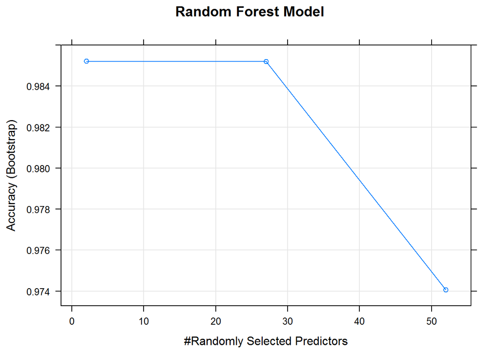

```r
# Use the models to predict the test set
predictRFtest <- predict(modfitRF, newdata = testing)
predictGBMtest <- predict(modfitGBM, newdata = testing)

#Plot of each model
plot(modfitRF, main="Random Forest Model")
```

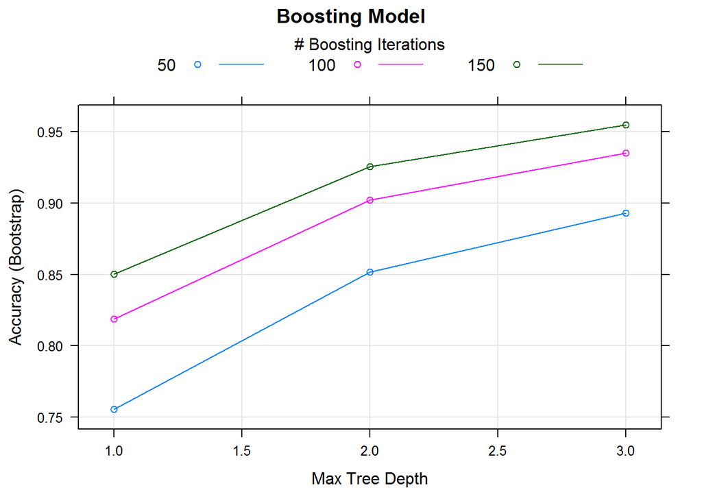

```r
plot(modfitGBM, main="Boosting Model")
```

```r
#Compute confusion matrices
table(predictRFtest,testing$classe)
```

```
##
## predictRFtest    A    B    C    D    E
##             A 2229   14    1    0    0
##             B    3 1501   16    0    0
##             C    0    3 1349   32    1
##             D    0    0    2 1251    4
##             E    0    0    0    3 1437
```

```r
table(predictGBMtest,testing$classe)
```

```
##
## predictGBMtest    A    B    C    D    E
##              A 2201   38    0    0    6
##              B   20 1446   61    5   11
##              C    7   32 1293   47   16
##              D    4    0   11 1231   18
##              E    0    2    3    3 1391
```

```r
# Compute accuracy of the 2 models on the test set
RFAccuracy=table(predictRFtest == testing$classe)/length(testing$classe)
GBMAccuracy=table(predictGBMtest == testing$classe)/length(testing$classe)
```

Notice that our accuracy for the random forest model is 0.9899! The accuracy for the boosting model is not quite as good at 0.9638.

### Model Fitting Using a Stacked Model

Next, we consider a stacked model of the two methods. We build a data frame of the predicted training data using the two models, then fit our stacked model to this new data frame.

```r
#Compute the predicted training for the stacked model
predictRFtrain <- predict(modfitRF, newdata = training)
predictGBMtrain <- predict(modfitGBM, newdata = training)

# Use the predictions on the training set as 2 features for a stacked model
predictionDataFrame <- data.frame(varRF = predictRFtrain, varGBM = predictGBMtrain, classe = training$classe)
modfitStacked <- train(classe~., method = "rf", data = predictionDataFrame)
```

### Cross Validation on Stacked Model

A similar testing data frame is built in order to perform cross validation on the stacked model. We again compute the confusion matrix and the accuracy.

```r
# Now build the test data frame containing the features for the testing set for the stacked model
testingStacked <- data.frame(varRF = predictRFtest, varGBM= predictGBMtest, classe = testing$classe)
dim(testingStacked)
```

```
## [1] 7846    3
```

```r
predictStacked <- predict(modfitStacked, newdata = testingStacked)
# Get accuracy of stacked model on the test set

#Display table
table(predictStacked,testing$classe)
```

```
##
## predictStacked    A    B    C    D    E
##              A 2229   14    1    0    0
##              B    3 1501   16    0    0
##              C    0    3 1349   32    1
##              D    0    0    2 1251    4
##              E    0    0    0    3 1437
```

```r
#Accuracy
StackedAccuracy=table(predictStacked == testing$classe)/length(testing$classe)
```

Notice that the accuracy for this stacked model is 0.9899. Since this accuracy is the same as the random forest model, we simply use the random forest model as it is a simpler model.

### Applying Model to Test Cases

Finally, we use our random forest model to predict the 20 test cases and display the answers as below.

```r
FinalTest=predict(modfitRF,newdata=TestData)
FinalTest
```

```
##  [1] B A B A A E D B A A B C B A E E A B B B
## Levels: A B C D E
```

```r
Answers=as.character(FinalTest)
```

### Conclusion

In this report, we have used three different models (random forest, boosting, and a stacked model of the two) to quantify dumbbell curls of six individuals. We observe that all three methods perform quite well on our cross validation set, but choose the random forest model as the simplest model with highest accuracy.

### Bibliography

[1] Velloso, E.; Bulling, A.; Gellersen, H.; Ugulino, W.; Fuks, H. Qualitative Activity Recognition of Weight Lifting Exercises. Proceedings of 4th International Conference in Cooperation with SIGCHI (Augmented Human ’13) . Stuttgart, Germany: ACM SIGCHI, 2013.